# Titanic Survivor Analysis 2

BryanEng

November 7, 2018

```r
library(caTools)
library(caret)
library(randomForest)
library(pROC)
library(e1071)
set.seed(1)
```

```r
train.set = read.csv("Titanic.Train.csv")
test.set = read.csv("Titanic.Test.csv")
# summary(train.set)
# summary(test.set)
```

## Task 1

Use package randomForest to learn a random forest from the training data with the number of trees set to 100. Apply the random forest model to predict the class labels of the test data. What is the accuracy of the model? Using the pROC package, plot the ROC curve of your random forest model. What is the AUC? How does the performance of the best random forest model compare to that of the best decision tree model from Programming Assignment 2?

```r
random.model = randomForest(as.factor(survived) ~ pclass + sex + age + sibsp + parch + fare,
                      ntree = 100, data = train.set, proximity=TRUE, importance = TRUE)
random.model
```

```
##
## Call:
##  randomForest(formula = as.factor(survived) ~ pclass + sex + age +      sibsp + parch + fare, data = train.set, ntree = 100, proximity = TRUE,      importance = TRUE)
##                Type of random forest: classification
##                      Number of trees: 100
## No. of variables tried at each split: 2
##
##         OOB estimate of  error rate: 16.52%
## Confusion matrix:
##     0   1 class.error
## 0 595  54  0.08320493
## 1 119 279  0.29899497
```

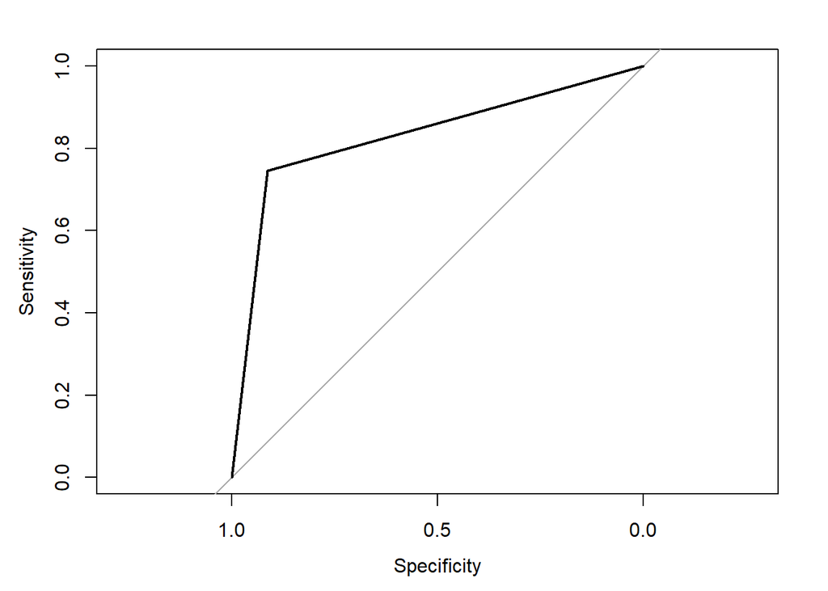

```r
random.predict = predict(random.model, test.set, probability = TRUE)
random.roc = roc(as.numeric(test.set$survived), as.numeric(random.predict))
plot(random.roc)
```

```r
auc(random.roc)
```

```
## Area under the curve: 0.8288
```

```r
confusionMatrix(data = random.predict, reference = as.factor(test.set$survived))
```

```
## Confusion Matrix and Statistics
##
##           Reference
## Prediction   0   1
##          0 146  26
##          1  14  76
##
##                Accuracy : 0.8473
##                  95% CI : (0.798, 0.8886)
##     No Information Rate : 0.6107
##     P-Value [Acc > NIR] : < 2e-16
##
##                   Kappa : 0.6719
##  Mcnemar's Test P-Value : 0.08199
##
##             Sensitivity : 0.9125
##             Specificity : 0.7451
##          Pos Pred Value : 0.8488
##          Neg Pred Value : 0.8444
##              Prevalence : 0.6107
##          Detection Rate : 0.5573
##    Detection Prevalence : 0.6565
##       Balanced Accuracy : 0.8288
##
##        'Positive' Class : 0
##
```

## Task 2

Use functions importance() and varImpPlot() to analyze the importance of the different attributes across the whole forest. Report the top three most important attributes in decreasing order of importance and explain their relevance for the classification task.

```r
random.importance = importance(random.model)
random.importance
```

```
##                0         1 MeanDecreaseAccuracy MeanDecreaseGini
## pclass 10.510064 14.526739            18.830770         35.83508
## sex    28.061451 37.559776            38.614178        109.82777
## age    14.846418 18.467695            22.623029         98.32030
## sibsp   9.825383  1.589280             8.915329         18.64789
## parch   6.696466  3.970826             8.755189         17.02453
## fare    7.015237 10.165904            12.384418         78.92022
```

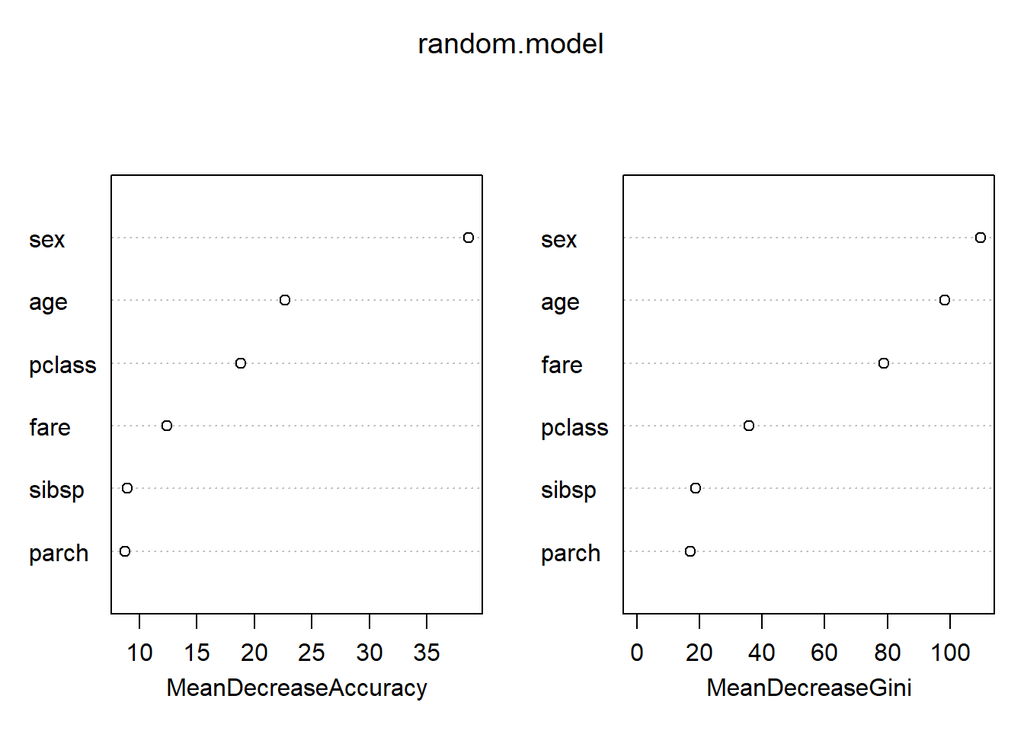

```r
random.varPlot = varImpPlot(random.model, sort=TRUE)
```

Pclass, sex, and age are listed as the three most important attributes. Of these three, sex is the most important deciding factor, while age and pclass are less in comparison. It makes sense that sex would be the most important, as women are most likely to board the lifeboats first. Age comes next, because those women are likely to carry their newborns with them, and young adults who are more able-bodied should be able to make it onboard with greater likelyhood. Finally, the class determines survival rate as 1st and 2nd class passengers would likely be escorted to the lifeboats before the 3rd class passengers.

## Task 3

Learn a logistic regression model from the training data using the caret package and the glmnet method of the function train(). What are the most significant three attributes of your model?

```r
log.model = train(survived ~ ., data = train.set, method = "glmnet", family="binomial")
summary(log.model)
```

```
##             Length Class      Mode
## a0           61    -none-     numeric
## beta        366    dgCMatrix  S4
## df           61    -none-     numeric
## dim           2    -none-     numeric
## lambda       61    -none-     numeric
## dev.ratio    61    -none-     numeric
## nulldev       1    -none-     numeric
## npasses       1    -none-     numeric
## jerr          1    -none-     numeric
## offset        1    -none-     logical
## classnames    2    -none-     character
## call          5    -none-     call
## nobs          1    -none-     numeric
## lambdaOpt     1    -none-     numeric
## xNames        6    -none-     character
## problemType   1    -none-     character
## tuneValue     2    data.frame list
## obsLevels     1    -none-     logical
## param         1    -none-     list
```

```r
varImp(log.model)
```

```
## glmnet variable importance
##
##           Overall
## sexmale 100.00000
## pclass   24.93271
## age       0.06531
## sibsp     0.00000
## parch     0.00000
## fare      0.00000
```

As expected, the pclass, sex, and age attributes have the highest importance values. The other attributes all have scores of 0, which may mean that their importance is insignificant to calculating the logistic regression.

## Task 4

Apply the logistic regression model to predict the class labels of the test data. Plot the confusion matrix. What is the accuracy of the model? Plot the ROC curve of your logistic regression model. What is the AUC of your logistic regression model?

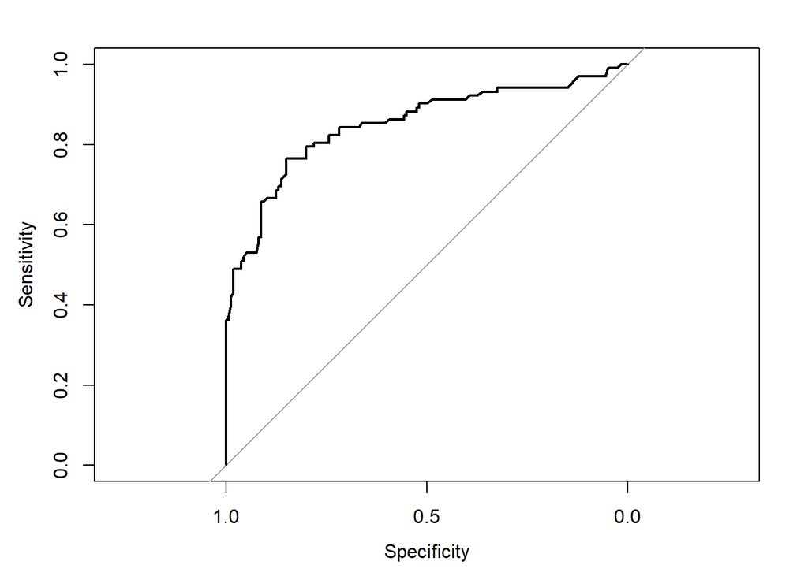

```r
logistic.predict = predict(log.model, test.set, probability=TRUE)
logistic.roc = roc(as.numeric(test.set$survived), as.numeric(logistic.predict))
plot(logistic.roc)
```

```r
logistic.predict.vals = as.factor(as.numeric(logistic.predict>0.5))
confusionMatrix(data = logistic.predict.vals, reference = as.factor(test.set$survived))
```

```
## Confusion Matrix and Statistics
##
##           Reference
## Prediction   0   1
##          0 157  53
##          1   3  49
##
##                Accuracy : 0.7863
##                  95% CI : (0.7316, 0.8343)
##     No Information Rate : 0.6107
##     P-Value [Acc > NIR] : 9.735e-10
##
##                   Kappa : 0.5067
##  Mcnemar's Test P-Value : 5.835e-11
##
##             Sensitivity : 0.9812
##             Specificity : 0.4804
##          Pos Pred Value : 0.7476
##          Neg Pred Value : 0.9423
##              Prevalence : 0.6107
##          Detection Rate : 0.5992
##    Detection Prevalence : 0.8015
##       Balanced Accuracy : 0.7308
##
##        'Positive' Class : 0
##
```

```r
auc(logistic.roc)
```

```
## Area under the curve: 0.85
```

The AUC of the logistic regression is 0.85. Its accuracy is 78.63%.

## Task 5

Learn SVM models from the training data, using linear and radial kernels from package e1071. Using the function tune(), obtain the best parameters for linear and for radial kernels. What are the best parameters for the linear and for the radial kernel? Discuss the results.

```r
linear.tune = tune(svm, survived ~ ., data = train.set, kernel="linear",
                   ranges = list(cost=c(0.001, 0.01, 0.1, 1),
                                 gamma=c(0.00001, 0.0001, 0.001, 0.01, 0.1)))
summary(linear.tune)
```

```
##
## Parameter tuning of 'svm':
##
## - sampling method: 10-fold cross validation
##
## - best parameters:
##  cost gamma
##  0.01 1e-05
##
## - best performance: 0.1993102
##
## - Detailed performance results:
##     cost gamma     error dispersion
## 1  0.001 1e-05 0.2437126 0.03058536
## 2  0.010 1e-05 0.1993102 0.04231771
## 3  0.100 1e-05 0.2050274 0.03891543
## 4  1.000 1e-05 0.2050265 0.03891809
## 5  0.001 1e-04 0.2437126 0.03058536
## 6  0.010 1e-04 0.1993102 0.04231771
## 7  0.100 1e-04 0.2050274 0.03891543
## 8  1.000 1e-04 0.2050265 0.03891809
## 9  0.001 1e-03 0.2437126 0.03058536
## 10 0.010 1e-03 0.1993102 0.04231771
## 11 0.100 1e-03 0.2050274 0.03891543
## 12 1.000 1e-03 0.2050265 0.03891809
## 13 0.001 1e-02 0.2437126 0.03058536
## 14 0.010 1e-02 0.1993102 0.04231771
## 15 0.100 1e-02 0.2050274 0.03891543
## 16 1.000 1e-02 0.2050265 0.03891809
## 17 0.001 1e-01 0.2437126 0.03058536
## 18 0.010 1e-01 0.1993102 0.04231771
## 19 0.100 1e-01 0.2050274 0.03891543
## 20 1.000 1e-01 0.2050265 0.03891809
```

```r
linear.svm = svm(survived ~ ., data = train.set, kernel = "linear",
                 cost = linear.tune$best.parameters$cost,
                 gamma = linear.tune$best.parameters$gamma, scale = FALSE)
summary(linear.svm)
```

```
##
## Call:
## svm(formula = survived ~ ., data = train.set, kernel = "linear",
##     cost = linear.tune$best.parameters$cost, gamma = linear.tune$best.parameters$gamma,
##     scale = FALSE)
##
##
## Parameters:
##    SVM-Type:  eps-regression
##  SVM-Kernel:  linear
##        cost:  0.01
##       gamma:  1e-05
##     epsilon:  0.1
##
##
## Number of Support Vectors:  584
```

```r
radial.tune = tune(svm, survived ~ ., data = train.set, kernel="radial",
                   ranges = list(cost=c(0.001, 0.01, 0.1, 1, 5),
                                 gamma=c(0.001, 0.01, 0.1, 1, 5)))
summary(radial.tune)
```

```
##
## Parameter tuning of 'svm':
##
## - sampling method: 10-fold cross validation
##
## - best parameters:
##  cost gamma
##   0.1   0.1
##
## - best performance: 0.164382
##
## - Detailed performance results:
##     cost gamma     error dispersion
## 1  0.001 0.001 0.3454433 0.03209437
## 2  0.010 0.001 0.3431527 0.03206757
## 3  0.100 0.001 0.3218433 0.03194253
## 4  1.000 0.001 0.1933279 0.02888069
## 5  5.000 0.001 0.1948018 0.03967899
## 6  0.001 0.010 0.3434942 0.03208225
## 7  0.010 0.010 0.3248120 0.03182775
## 8  0.100 0.010 0.1962460 0.02879467
## 9  1.000 0.010 0.1882239 0.03443887
## 10 5.000 0.010 0.1844527 0.03505673
## 11 0.001 0.100 0.3366447 0.03190027
## 12 0.010 0.100 0.2656325 0.03046389
## 13 0.100 0.100 0.1643820 0.03432309
## 14 1.000 0.100 0.1685004 0.03452465
## 15 5.000 0.100 0.1685728 0.03557773
## 16 0.001 1.000 0.3410304 0.03208008
## 17 0.010 1.000 0.3026169 0.03193012
## 18 0.100 1.000 0.1673280 0.02880337
## 19 1.000 1.000 0.1692071 0.03279838
## 20 5.000 1.000 0.1850206 0.03280815
## 21 0.001 5.000 0.3441758 0.03208225
## 22 0.010 5.000 0.3317893 0.03202219
## 23 0.100 5.000 0.2371262 0.02957380
## 24 1.000 5.000 0.1802466 0.02497979
## 25 5.000 5.000 0.1885670 0.02332612
```

```r
radial.svm = svm(survived ~ ., data = train.set, kernel = "radial",
                 cost = radial.tune$best.parameters$cost,
                 gamma = radial.tune$best.parameters$gamma, scale = FALSE)
summary(radial.svm)
```

```
##
## Call:
## svm(formula = survived ~ ., data = train.set, kernel = "radial",
##     cost = radial.tune$best.parameters$cost, gamma = radial.tune$best.parameters$gamma,
##     scale = FALSE)
##
##
## Parameters:
##    SVM-Type:  eps-regression
##  SVM-Kernel:  radial
##        cost:  0.1
##       gamma:  0.1
##     epsilon:  0.1
##
##
## Number of Support Vectors:  830
```

## Task 6

Apply the best SVM model to predict the class labels of the test data. Plot the confusion matrix. What is the accuracy of the model? Plot the ROC curve of your best SVM model. What is the AUC of the model?

The linear svm:

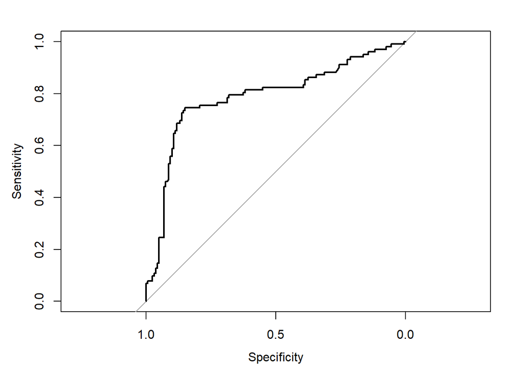

```r
linear.svm.predict = predict(linear.svm, test.set, probability = TRUE)
linear.svm.roc = roc(as.numeric(test.set$survived), as.numeric(linear.svm.predict))
plot(linear.svm.roc)
```

```r
linear.svm.predict.vals = as.factor(as.numeric(linear.svm.predict>0.5))
confusionMatrix(data = linear.svm.predict.vals, reference = as.factor(test.set$survived))
```

```
## Confusion Matrix and Statistics
##
##           Reference
## Prediction   0   1
##          0 138  31
##          1  22  71
##
##                Accuracy : 0.7977
##                  95% CI : (0.7439, 0.8446)
##     No Information Rate : 0.6107
##     P-Value [Acc > NIR] : 6.631e-11
##
##                   Kappa : 0.5677
##  Mcnemar's Test P-Value : 0.2718
##
##             Sensitivity : 0.8625
##             Specificity : 0.6961
##          Pos Pred Value : 0.8166
##          Neg Pred Value : 0.7634
##              Prevalence : 0.6107
##          Detection Rate : 0.5267
##    Detection Prevalence : 0.6450
##       Balanced Accuracy : 0.7793
##
##        'Positive' Class : 0
##
```

```r
auc(linear.svm.roc)
```

```
## Area under the curve: 0.7859
```

The radial svm:

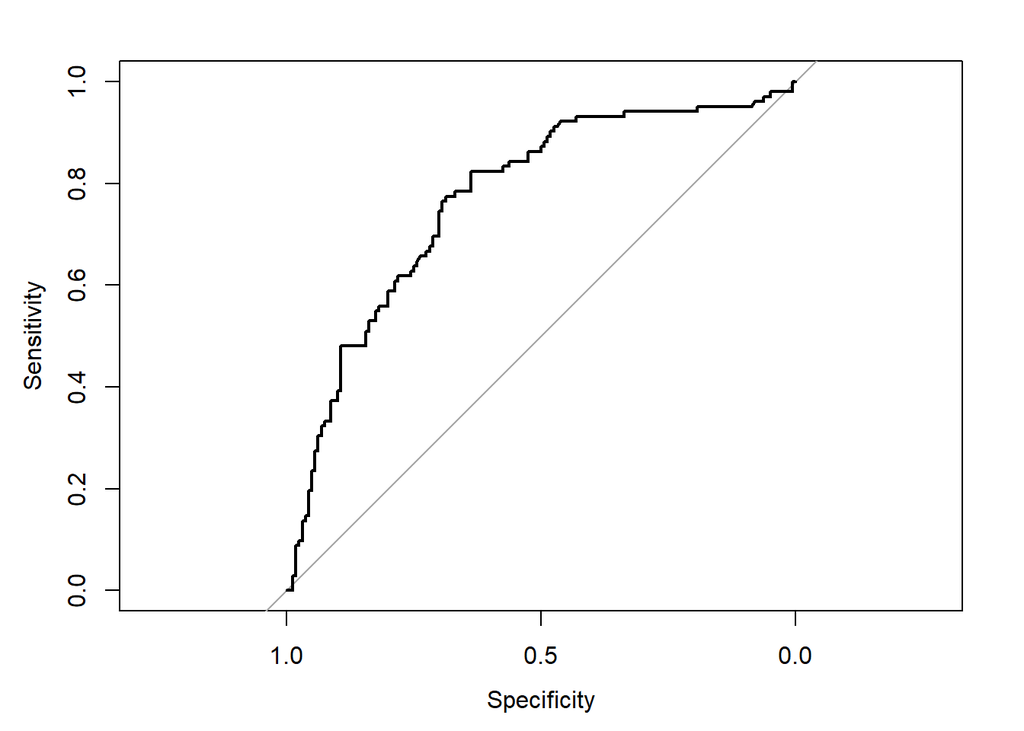

```r
radial.svm.predict = predict(radial.svm, test.set, probability = TRUE)
radial.svm.roc = roc(as.numeric(test.set$survived), as.numeric(radial.svm.predict))
plot(radial.svm.roc)
```

```r
radial.svm.predict.vals = as.factor(as.numeric(radial.svm.predict>0.5))
confusionMatrix(data = radial.svm.predict.vals, reference = as.factor(test.set$survived))
```

```
## Confusion Matrix and Statistics
##
##           Reference
## Prediction   0   1
##          0 155  92
##          1   5  10
##
##                Accuracy : 0.6298
##                  95% CI : (0.5682, 0.6884)
##     No Information Rate : 0.6107
##     P-Value [Acc > NIR] : 0.2854
##
##                   Kappa : 0.079
##  Mcnemar's Test P-Value : <2e-16
##
##             Sensitivity : 0.96875
##             Specificity : 0.09804
##          Pos Pred Value : 0.62753
##          Neg Pred Value : 0.66667
##              Prevalence : 0.61069
##          Detection Rate : 0.59160
##    Detection Prevalence : 0.94275
##       Balanced Accuracy : 0.53339
##
##        'Positive' Class : 0
##
```

```r
auc(radial.svm.roc)
```

```
## Area under the curve: 0.7692
```

## Graphs and Plots Generated

These are in the folder images

[figure not shown]

Random Forest ROC

[figure not shown]

Random Forest Variable Importance

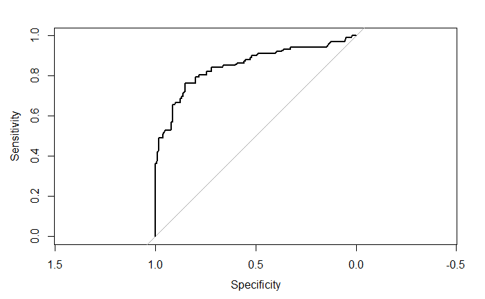

Logistic Regression ROC

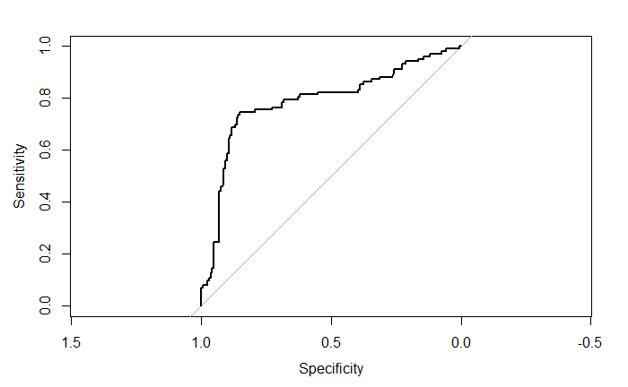

Linear SVM ROC

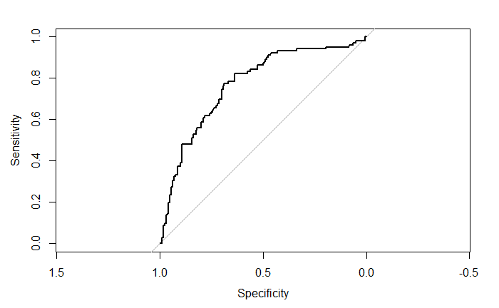

Radial SVM ROC